# Soil Nutrient EDA

Abhishek Sinha

January 9, 2018

## Loading Data

```r
soil_df <- fread("../Soil_Nutrient_Year.csv", header = T, stringsAsFactors = F, showProgress = T)
soil_df$V1 <- NULL
```

## Summary of Soil Nutrient Data Set

```r
summary(soil_df)
```

```
##    DistrictId    DistrictName          BlockId        BlockName
##  Min.   :69.00   Length:685478      Min.   : 447.0   Length:685478
##  1st Qu.:74.00   Class :character   1st Qu.: 483.0   Class :character
##  Median :78.00   Mode  :character   Median : 515.0   Mode  :character
##  Mean   :77.97                      Mean   : 615.4
##  3rd Qu.:81.00                      3rd Qu.: 539.0
##  Max.   :89.00                      Max.   :6778.0
##
##      SoilPh       ElectricalConductivity OrganicCarbon
##  Min.   : 0.010   Min.   :0.000          Min.   : 0.0000
##  1st Qu.: 7.580   1st Qu.:0.340          1st Qu.: 0.2500
##  Median : 7.810   Median :0.520          Median : 0.3200
##  Mean   : 7.992   Mean   :0.678          Mean   : 0.4949
##  3rd Qu.: 8.100   3rd Qu.:0.800          3rd Qu.: 0.3900
##  Max.   :96.000   Max.   :5.000          Max.   :97.1400
##  NA's   :6319     NA's   :7917           NA's   :1093
##     Nitrogen       Phosphorous        Potassium          Sulphur
##  Min.   :   0.1   Min.   :   0.00   Min.   :   0.00   Min.   :  0.00
##  1st Qu.:  61.4   1st Qu.:   4.90   1st Qu.:  93.39   1st Qu.: 19.80
##  Median :  77.9   Median :   8.70   Median : 172.00   Median : 44.48
##  Mean   :  82.6   Mean   :  16.70   Mean   : 238.89   Mean   : 71.58
##  3rd Qu.:  97.1   3rd Qu.:  14.49   3rd Qu.: 326.17   3rd Qu.: 92.98
##  Max.   :9714.0   Max.   :9890.00   Max.   :9980.00   Max.   :999.00
##  NA's   :659896   NA's   :2639      NA's   :2643      NA's   :30037
##       Zinc              Iron            Copper         Magnesium
##  Min.   :  0.000   Min.   :  0.00   Min.   :  0.0    Min.   :  0.000
##  1st Qu.:  0.750   1st Qu.:  4.29   1st Qu.:  0.6    1st Qu.:  2.440
##  Median :  1.370   Median :  7.77   Median :  1.1    Median :  4.740
##  Mean   :  3.423   Mean   : 13.42   Mean   :  2.9    Mean   :  9.157
##  3rd Qu.:  2.520   3rd Qu.: 14.06   3rd Qu.:  2.1    3rd Qu.:  9.090
##  Max.   :996.000   Max.   :999.00   Max.   :984.7    Max.   :999.000
##  NA's   :5764      NA's   :5647     NA's   :352636   NA's   :9963
##      Boron             Year
##  Min.   :  0.0    Min.   :2013
##  1st Qu.:  0.3    1st Qu.:2015
##  Median :  1.4    Median :2015
##  Mean   : 18.0    Mean   :2015
##  3rd Qu.: 10.1    3rd Qu.:2015
##  Max.   :937.6    Max.   :2016
##  NA's   :680505
```

## PH

```r
table(is.na(soil_df$SoilPh))
```

```
##
##  FALSE   TRUE
## 679159   6319
```

```r
table(soil_df$SoilPh>14) # 1652 records have incorrect data (<1%)
```

```
##
##  FALSE   TRUE
## 677507   1652
```

6319 is missing data (<1%).  
1652 rows have incorrect data, >14.

Average value: 7.9917812

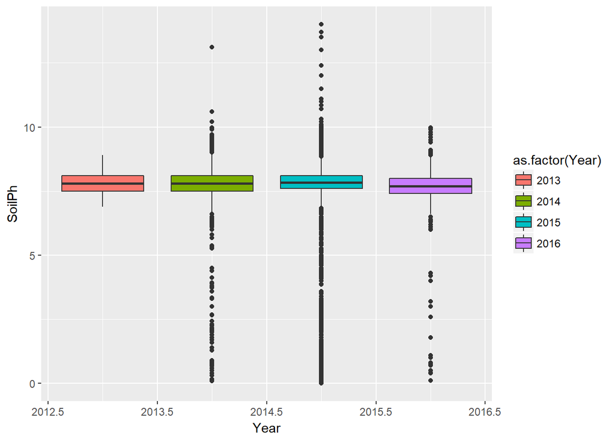

```r
ggplot(data=soil_df[soil_df$SoilPh<=14,], aes(x=Year, y=SoilPh, fill=as.factor(Year))) + geom_boxplot()
```

## Electrical Conductivty

```r
table(is.na(soil_df$ElectricalConductivity))
```

```
##
##  FALSE   TRUE
## 677561   7917
```

7917 missing value in EC (~1%).

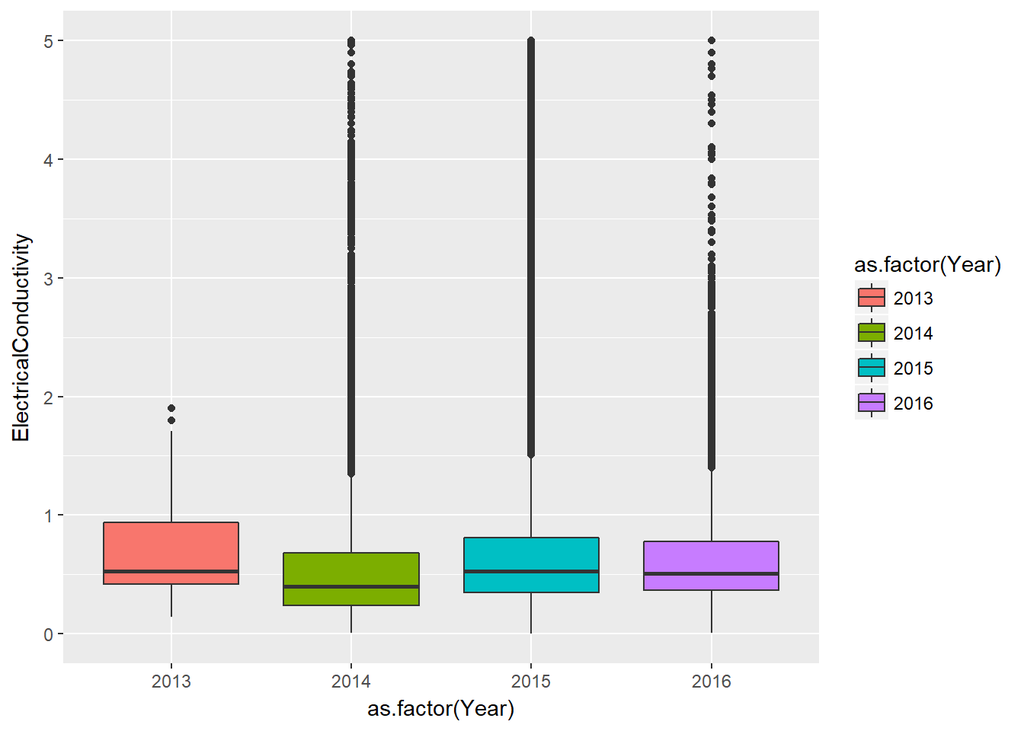

```r
ggplot(data=soil_df, aes(x=as.factor(Year), y=ElectricalConductivity, fill=as.factor(Year))) + geom_boxplot()
```

Looking at the historgram

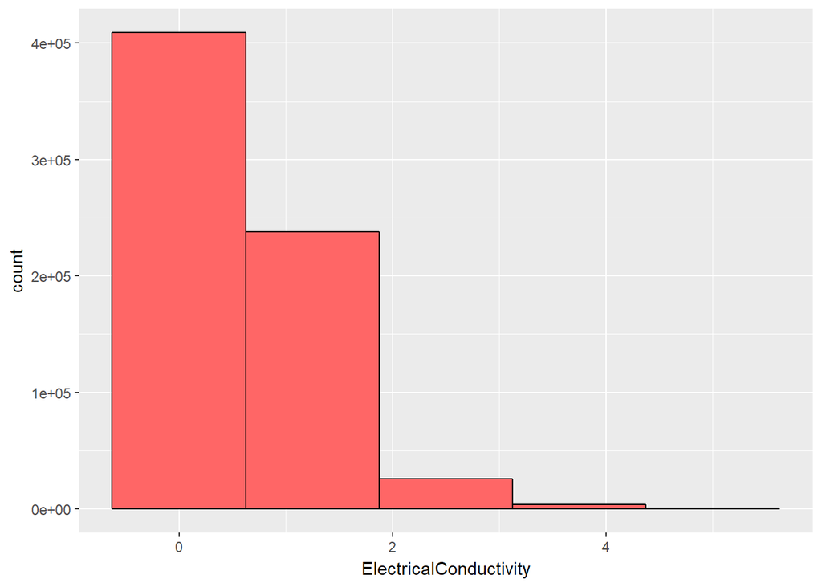

```r
ggplot(soil_df) + aes(x = ElectricalConductivity) + geom_histogram(bins = 5, colour ="black", fill="#FF6666")
```

## Organic Compund

Missing values

```r
table(is.na(soil_df$OrganicCarbon))
```

```
##
##  FALSE   TRUE
## 684385   1093
```

1093 missing vales. Mean value: 0.494917.

OC above 1 vs less than 1

```r
table(soil_df$OrganicCarbon<=1)
```

```
##
##  FALSE   TRUE
##   4850 679535
```

Only 0.7086654% of OC value is above 1. Some treatment is required.

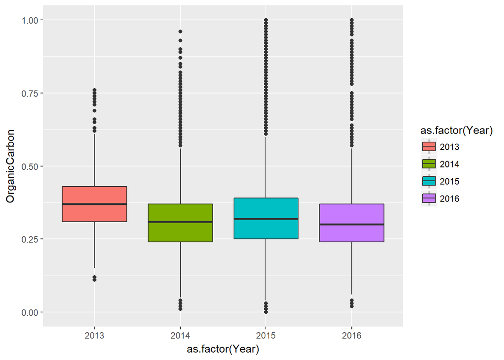

```r
temp <- soil_df[soil_df$OrganicCarbon<=1,]
ggplot(data=temp, aes(x=as.factor(Year), y=OrganicCarbon, fill=as.factor(Year))) + geom_boxplot()
```

```r
rm(temp)
```

## Nitrogen

Missing Values

```r
table(is.na(soil_df$Nitrogen))
```

```
##
##  FALSE   TRUE
##  25582 659896
```

Majority of data is missing for Nitrogen. (96.2680057%)

HYPOTHESIS: Organic Compound (OC) can be used as the proxy variable for Nitrogen.

### Bi-variate analysis of OC and N

```r
data_nit_oc <- soil_df[is.na(soil_df$Nitrogen)==F & is.na(soil_df$OrganicCarbon)==F,]
summary(lm(Nitrogen ~ OrganicCarbon, data_nit_oc))
```

```
##
## Call:
## lm(formula = Nitrogen ~ OrganicCarbon, data = data_nit_oc)
##
## Residuals:
##    Min     1Q Median     3Q    Max
## -125.7  -21.7   -5.2   14.0 9630.8
##
## Coefficients:
##               Estimate Std. Error t value Pr(>|t|)
## (Intercept)    83.0228     0.8120 102.246   <2e-16 ***
## OrganicCarbon   0.4818     0.5842   0.825    0.409
## ---
## Signif. codes:  0 '***' 0.001 '**' 0.01 '*' 0.05 '.' 0.1 ' ' 1
##
## Residual standard error: 126.4 on 25412 degrees of freedom
## Multiple R-squared:  2.677e-05,  Adjusted R-squared:  -1.258e-05
## F-statistic: 0.6803 on 1 and 25412 DF,  p-value: 0.4095
```

Correlation value: 0.0051742.

Both R Square and Correlation clearly suggests that Nitrogen Value and OC values are not correlated.

Clearly, the hypothesis is incorrect.

With a very high missing values for Nitrogen, we can easily remove the variable.

## Phosphorous

Missing Values

```r
table(is.na(soil_df$Phosphorous))
```

```
##
##  FALSE   TRUE
## 682839   2639
```

Low Missing Value 0.3849868%.

Mean 16.7013626.

Box Plot

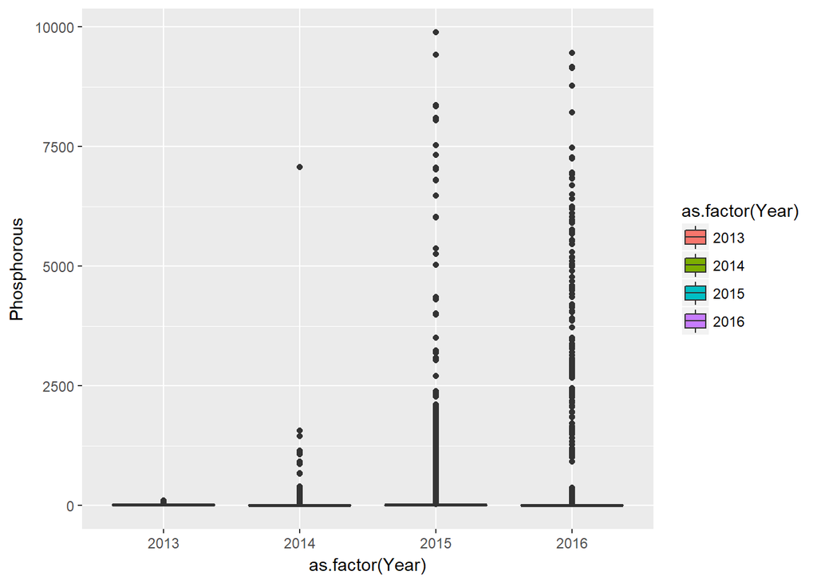

```r
ggplot(data=soil_df[is.na(soil_df$Phosphorous)==F,], aes(x=as.factor(Year), y=Phosphorous, fill=as.factor(Year))) + geom_boxplot()
```

```r
upper_lmt <- 14.49 + (1.5*IQR(soil_df$Phosphorous, na.rm = T)) #Taken from Summary
table(soil_df$Phosphorous<=upper_lmt)
```

```
##
##  FALSE   TRUE
##  70340 612499
```

Box Plot on log transformation

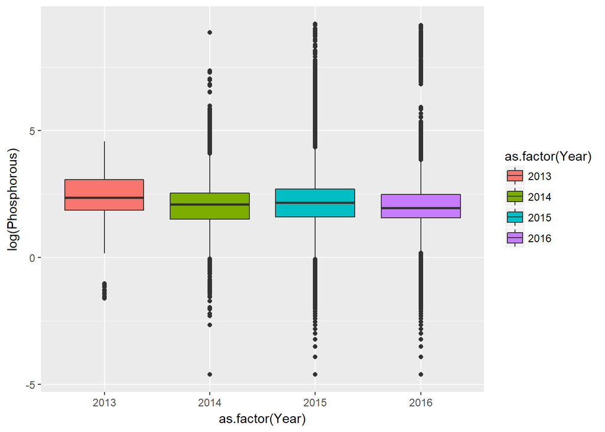

```r
ggplot(data=soil_df[is.na(soil_df$Phosphorous)==F,], aes(x=as.factor(Year), y=log(Phosphorous), fill=as.factor(Year))) + geom_boxplot()
```

The data looks normally distributed on log transformation.

## Potassium

Missing Values

```r
table(is.na(soil_df$Potassium))
```

```
##
##  FALSE   TRUE
## 682835   2643
```

Low Missing Value 0.3855704%.

Mean 238.8920928.

Box Plot

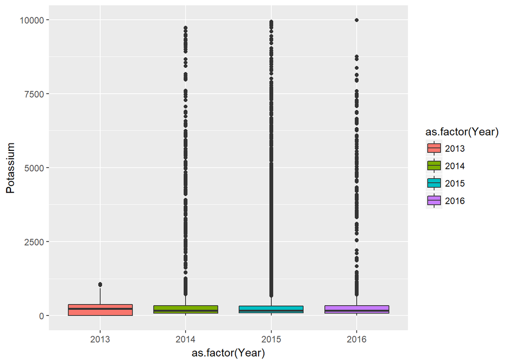

```r
ggplot(data=soil_df[is.na(soil_df$Potassium)==F,], aes(x=as.factor(Year), y=Potassium, fill=as.factor(Year))) + geom_boxplot()
```

Box Plot on log transformation

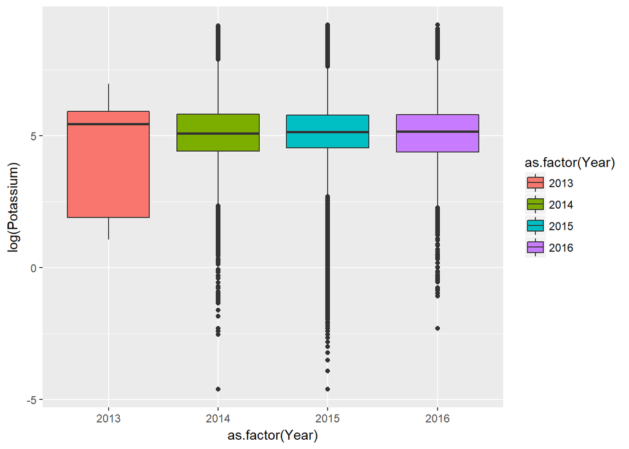

```r
ggplot(data=soil_df[is.na(soil_df$Potassium)==F,], aes(x=as.factor(Year), y=log(Potassium), fill=as.factor(Year))) + geom_boxplot()
```

Log transformation is highly normal distributed.

## Sulphur

Missing Values

```r
table(is.na(soil_df$Sulphur))
```

```
##
##  FALSE   TRUE
## 655441  30037
```

Low Missing Value 4.3819058%.

Mean 71.5763594.

Box Plot

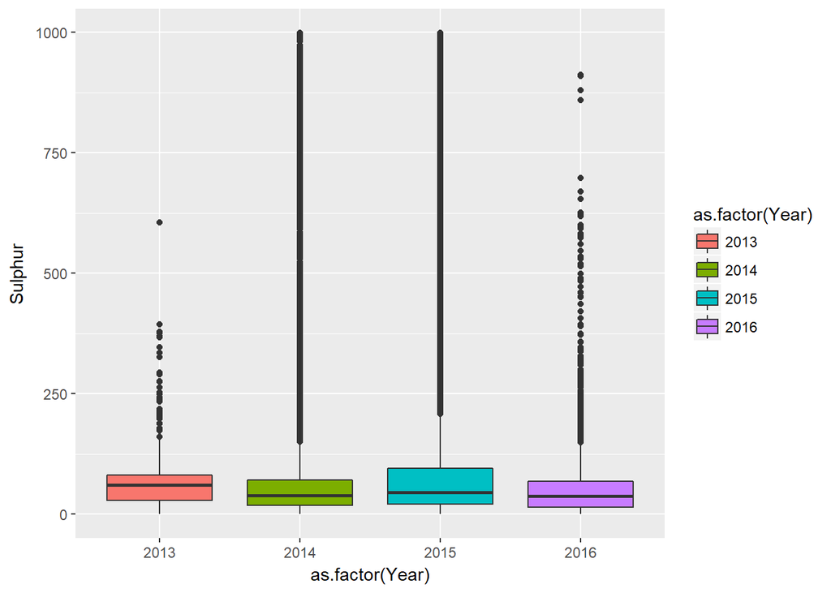

```r
ggplot(data=soil_df[is.na(soil_df$Sulphur)==F,], aes(x=as.factor(Year), y=Sulphur, fill=as.factor(Year))) + geom_boxplot()
```

Box Plot on log transformation

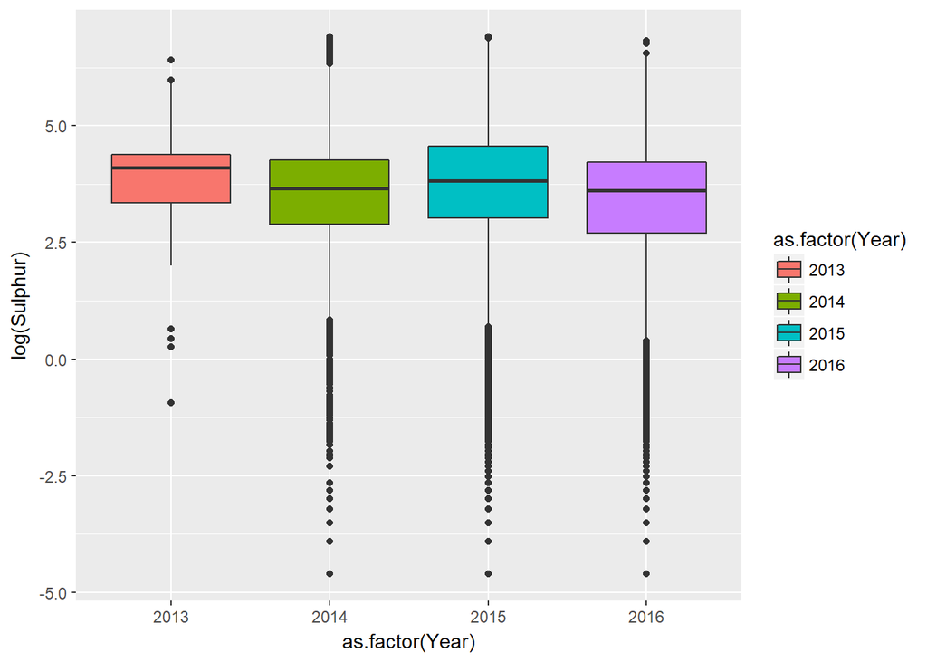

```r
ggplot(data=soil_df[is.na(soil_df$Sulphur)==F,], aes(x=as.factor(Year), y=log(Sulphur), fill=as.factor(Year))) + geom_boxplot()
```

Log transformation is normal distributed with a lttle skewness on left side.

## Zinc

Missing Values

```r
table(is.na(soil_df$Zinc))
```

```
##
##  FALSE   TRUE
## 679714   5764
```

Low Missing Value 0.8408731%.

Mean 3.4232712.

Box Plot

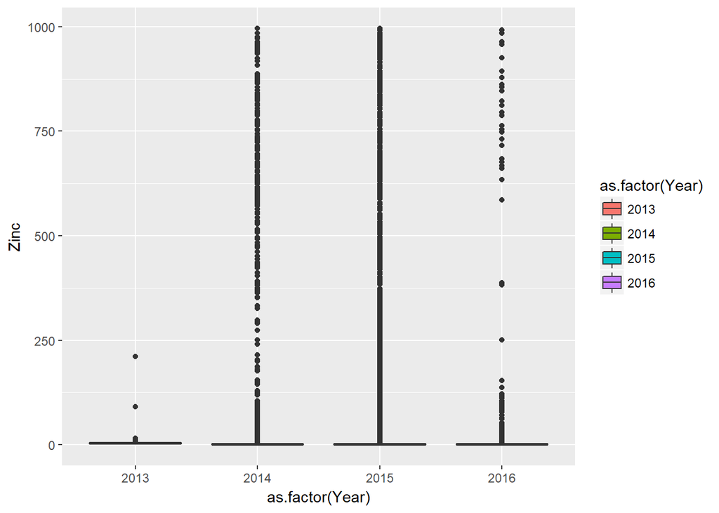

```r
ggplot(data=soil_df[is.na(soil_df$Zinc)==F,], aes(x=as.factor(Year), y=Zinc, fill=as.factor(Year))) + geom_boxplot()
```

Lot of outliers.

Box Plot on log transformation

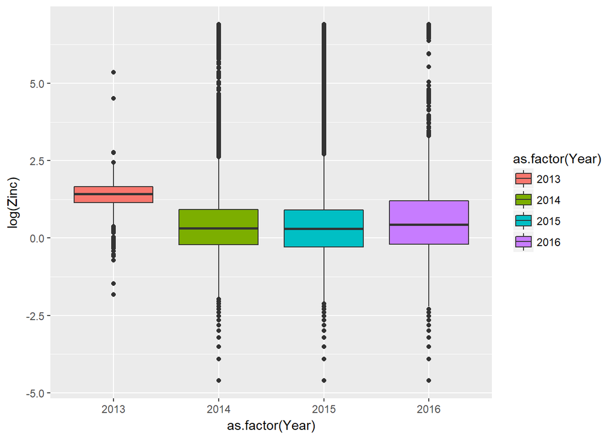

```r
ggplot(data=soil_df[is.na(soil_df$Zinc)==F,], aes(x=as.factor(Year), y=log(Zinc), fill=as.factor(Year))) + geom_boxplot()
```

Log transformation is normal distributed.

## Iron

Missing Values

```r
table(is.na(soil_df$Iron))
```

```
##
##  FALSE   TRUE
## 679831   5647
```

Low Missing Value 0.8238047%.

Mean 13.4236729.

Box Plot

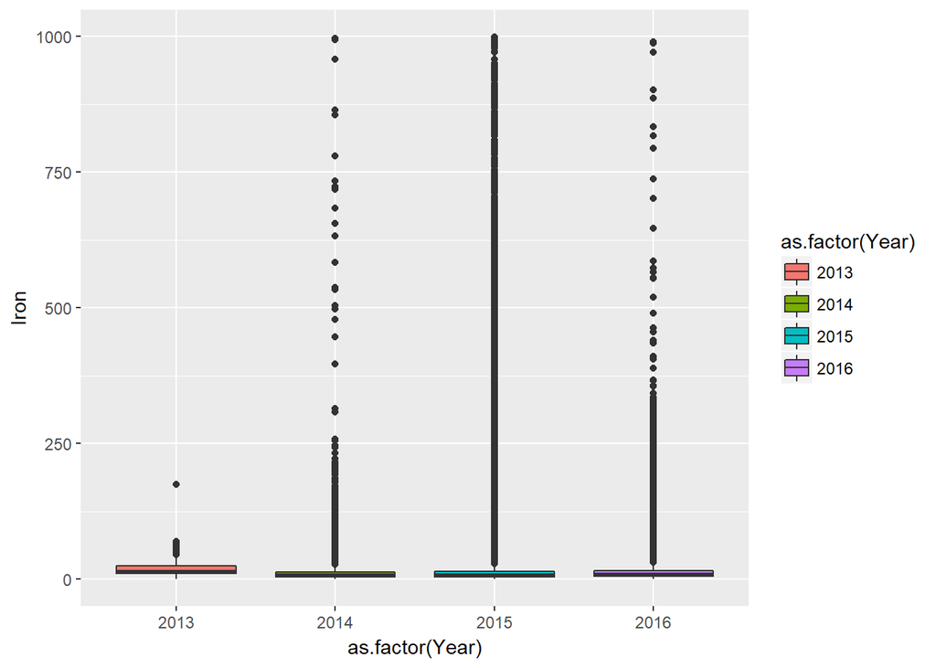

```r
ggplot(data=soil_df[is.na(soil_df$Iron)==F,], aes(x=as.factor(Year), y=Iron, fill=as.factor(Year))) + geom_boxplot()
```

Again lot of outliers.

Box Plot on log transformation

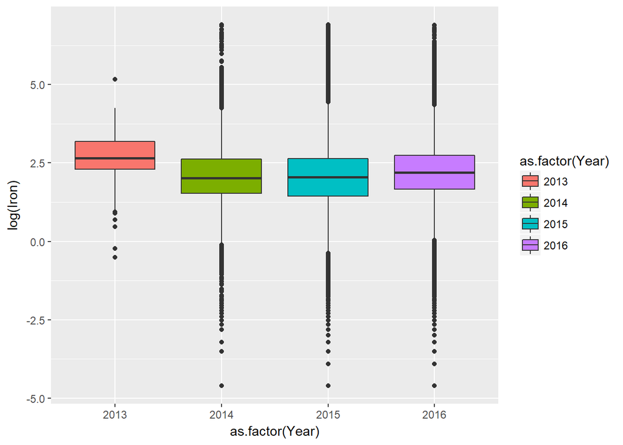

```r
ggplot(data=soil_df[is.na(soil_df$Iron)==F,], aes(x=as.factor(Year), y=log(Iron), fill=as.factor(Year))) + geom_boxplot()
```

Log transformation is normal distributed.

## Copper

Missing Values

```r
table(is.na(soil_df$Copper))
```

```
##
##  FALSE   TRUE
## 332842 352636
```

Very high Missing Value 51.44381%.

NEED TO DISCUSS

Mean 2.8994019.

Box Plot

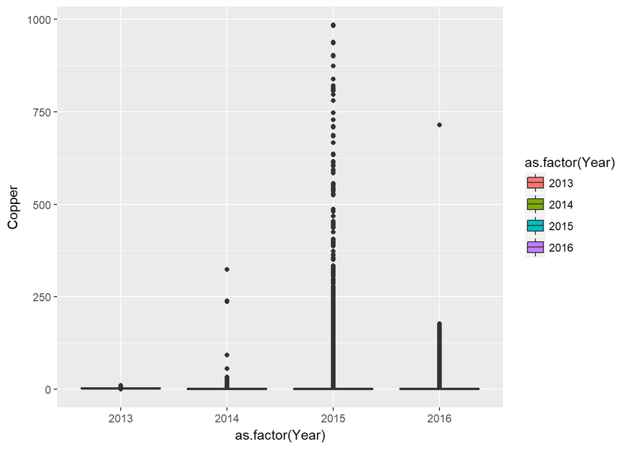

```r
ggplot(data=soil_df[is.na(soil_df$Copper)==F,], aes(x=as.factor(Year), y=Copper, fill=as.factor(Year))) + geom_boxplot()
```

Again lot of outliers.

Box Plot on log transformation

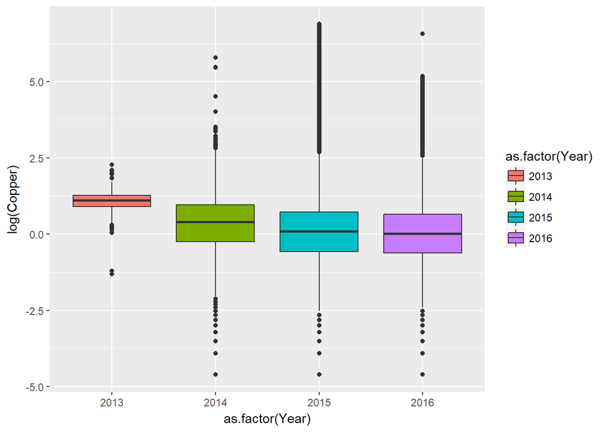

```r
ggplot(data=soil_df[is.na(soil_df$Copper)==F,], aes(x=as.factor(Year), y=log(Copper), fill=as.factor(Year))) + geom_boxplot()
```

Log transformation is normal distributed.

## Magnesium

Missing Values

```r
table(is.na(soil_df$Magnesium))
```

```
##
##  FALSE   TRUE
## 675515   9963
```

Missing Value of 1.4534383% is a little high but impuation should be fine. NEED TO DISCUSS.

Mean 9.1571879.

Box Plot

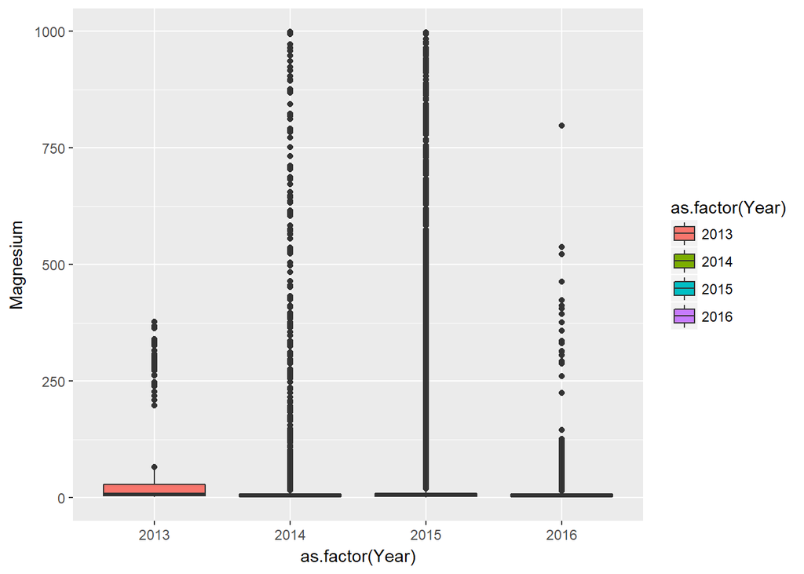

```r
ggplot(data=soil_df[is.na(soil_df$Magnesium)==F,], aes(x=as.factor(Year), y=Magnesium, fill=as.factor(Year))) + geom_boxplot()
```

Again lot of outliers.

Box Plot on log transformation

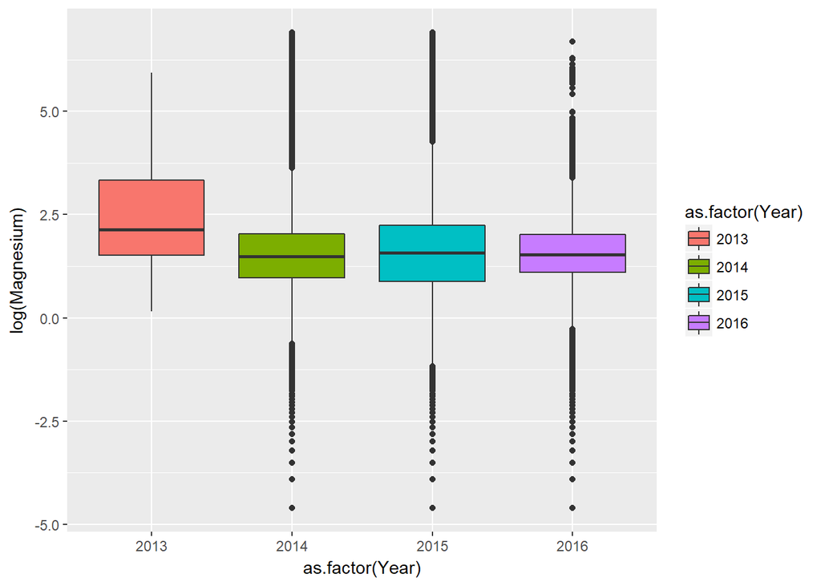

```r
ggplot(data=soil_df[is.na(soil_df$Magnesium)==F,], aes(x=as.factor(Year), y=log(Magnesium), fill=as.factor(Year))) + geom_boxplot()
```

Log transformation is normal distributed.

## Boron

Missing Values

```r
table(is.na(soil_df$Boron))
```

```
##
##  FALSE   TRUE
##   4973 680505
```

Almost all values are missing. Missing Value in 99.2745208% of data. NEED TO REMOVE THIS feature.